# US Accidents Exploratory Data Analysis

### Start Time analysis

```python
df.Start_Time
```

```
0          2016-02-08 00:37:08
1          2016-02-08 05:56:20
2          2016-02-08 06:15:39
3          2016-02-08 06:51:45
4          2016-02-08 07:53:43
                  ...
2845337    2019-08-23 18:03:25
2845338    2019-08-23 19:11:30
2845339    2019-08-23 19:00:21
2845340    2019-08-23 19:00:21
2845341    2019-08-23 18:52:06
Name: Start_Time, Length: 2845342, dtype: object
```

```python
df.Start_Time = pd.to_datetime(df.Start_Time)
```

```python
df.Start_Time[0]
```

```
Timestamp('2016-02-08 00:37:08')
```

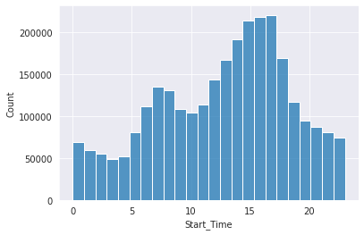

```python
sns.histplot(df.Start_Time.dt.hour, bins=24)
```

- A high percentage of accidents occur between 11am to 6pm.

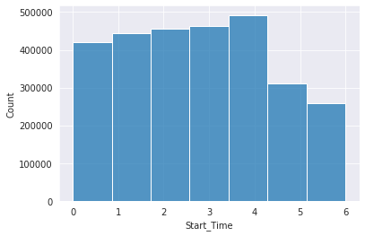

```python
sns.histplot(df.Start_Time.dt.dayofweek, bins=7)
```

- The accidents are lower on weekends and are almost evenly distributed in the weekdays
- Is the distribution of number accidents by hour the same on weekends as on weekdays???

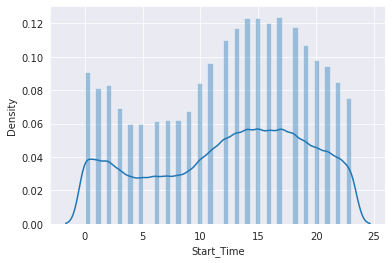

```python
sunday_start_time = df.Start_Time[df.Start_Time.dt.dayofweek == 6]
sns.distplot(sunday_start_time.dt.hour)
```

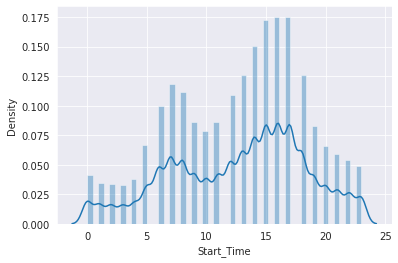

```python
monday_start_time = df.Start_Time[df.Start_Time.dt.dayofweek == 0]
sns.distplot(monday_start_time.dt.hour)
```

- On Sundays, the peak occurs between 10am and 8pm, unlike weekdays

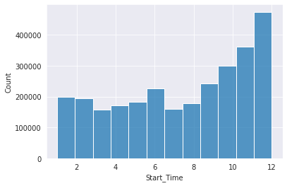

```python
sns.histplot(df.Start_Time.dt.month, bins=12)
```

- Need to dig deeper into the number of accidents per month. Seems like there are more accidents in the end of the year when the winter is there. More specifically, highest why in the december?
- Does more accidents occur in the winters?

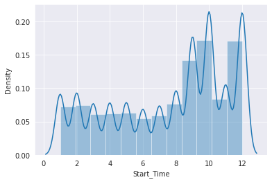

```python
df_by_2019 = df[df.Start_Time.dt.year == 2019]
sns.distplot(df_by_2019.Start_Time.dt.month, bins = 12)
```

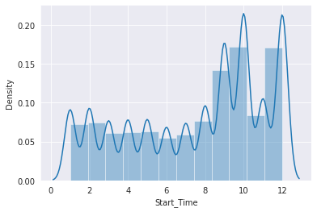

```python
df_by_2016 = df[df.Start_Time.dt.year == 2016]
sns.distplot(df_by_2019.Start_Time.dt.month, bins = 12)
```

Much data might be missing in different years due to which the distribution shows more accidents in Deceber.

- We also might have different sources of data. It might be important to compare the data from different sources.

### Start Latitude and Longitude Analysis

```python
df.Start_Lat, df.Start_Lng
```

```
(0          40.108910
 1          39.865420
 2          39.102660
 3          41.062130
 4          39.172393
              ...
 2845337    34.002480
 2845338    32.766960
 2845339    33.775450
 2845340    33.992460
 2845341    34.133930
 Name: Start_Lat, Length: 2845342, dtype: float64, 0          -83.092860
 1          -84.062800
 2          -84.524680
 3          -81.537840
 4          -84.492792
               ...
 2845337   -117.379360
 2845338   -117.148060
 2845339   -117.847790
 2845340   -118.403020
 2845341   -117.230920
 Name: Start_Lng, Length: 2845342, dtype: float64)
```

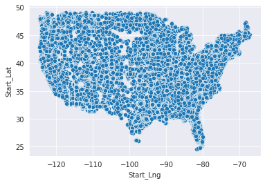

```python
sns.scatterplot(x=df.Start_Lng, y=df.Start_Lat)
```

```python
sample_df = df.sample(int(0.2 * len(df)))
```

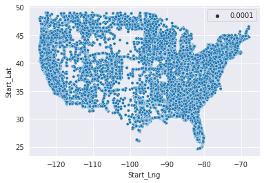

```python
sns.scatterplot(x=sample_df.Start_Lng, y=sample_df.Start_Lat, size = 0.0001)
```

```python
import folium
from folium.plugins import HeatMap
```

```python
lat, lng = df.Start_Lat[0], df.Start_Lng[0]
lat, lng
```

```
(40.10891, -83.09286)
```

```python
map = folium.Map()
```

```python
marker = folium.Marker((lat, lng))
marker.add_to(map)
map
```

Make this Notebook Trusted to load map: File -> Trust Notebook

[interactive chart not shown]

```python
list(zip(list(df.Start_Lat), list(df.Start_Lng)))
```

```python
sample1_df = df.sample(int(0.01*len(df)))
```

```python
lat_lng_pairs = list(zip(list(sample1_df.Start_Lat), (sample1_df.Start_Lng)))
```

```python
map1 = folium.Map()
HeatMap(lat_lng_pairs).add_to(map1)
map1
```

Make this Notebook Trusted to load map: File -> Trust Notebook

[interactive chart not shown]